# lincRNA

# independent hypothesis weighting

```r
library("IHW")
```

```r
resIHW <- results(deseq_linc, filterFun = ihw)
```

```
Only 1 bin; IHW reduces to Benjamini Hochberg (uniform weights)
```

```r
summary(resIHW)
```

```
out of 1187 with nonzero total read count
adjusted p-value < 0.1
LFC > 0 (up)       : 5, 0.42%
LFC < 0 (down)     : 1, 0.084%
outliers [1]       : 0, 0%
[1] see 'cooksCutoff' argument of ?results
see metadata(res)$ihwResult on hypothesis weighting
```

```r
sum(resIHW$padj < 0.1, na.rm = TRUE)
```

```
[1] 6
```

```r
metadata(resIHW)$ihwResult
```

```
ihwResult object with 1187 hypothesis tests
Nominal FDR control level: 0.1
Split into 1 bins, based on an ordinal covariate
```

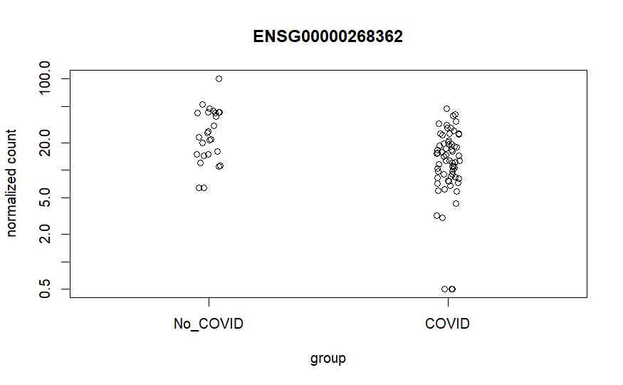

```r
plotCounts(deseq_linc, gene = which.min(res_l$padj), intgroup = "Cohort")
```

```r
d <- plotCounts(deseq_linc, gene = which.min(res_l$padj), intgroup = "Cohort",
                 returnData = TRUE)
ggplot(d, aes(x = Cohort, y = out_l)) +
  geom_point(position = position_jitter(w = 0.1, h = 0)) +
  scale_y_log10(breaks = c(25, 100, 400))
```

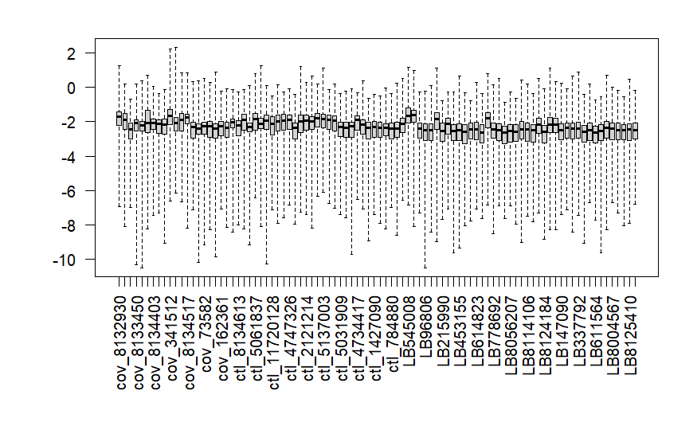

```r
par(mar = c(8, 5, 2, 2))
boxplot(log10(assays(deseq_linc)[["cooks"]]), range = 0, las = 2)
```

## Tests of log2 fold change above or below a threshold (lincRNA)

1.greaterAbs - |β|>x - tests are two-tailed  
2.lessAbs - |β|<x - p values are the maximum of the upper and lower tests  
3.greater - β>x  
4.less - β<−x

```r
par(mfrow=c(2,2),mar=c(2,2,1,1))
ylim <- c(-3, 3)
resGA <- results(deseq_linc, lfcThreshold=.5, altHypothesis="greaterAbs")
resLA <- results(deseq_linc, lfcThreshold=.5, altHypothesis="lessAbs")
resG <- results(deseq_linc, lfcThreshold=.5, altHypothesis="greater")
resL <- results(deseq_linc, lfcThreshold=.5, altHypothesis="less")
drawLines <- function() abline(h=c(-.5,.5),col="dodgerblue",lwd=2)
plotMA(resGA, ylim=ylim, cex=0.8, main="1"); drawLines()
plotMA(resLA, ylim=ylim, cex=0.8, main="2"); drawLines()
```

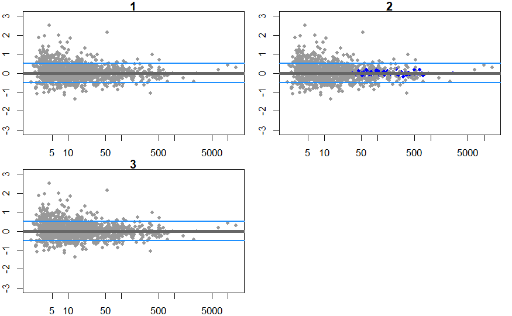

```r
plotMA(resG, ylim=ylim, cex=0.8, main="3"); drawLines()
plotMA(resL, ylim=ylim, cex=0.8, main="4"); drawLines()
```

## Tests of log2 fold change above or below a threshold (Protein Coding)

1.greaterAbs - |β|>x - tests are two-tailed  
2.lessAbs - |β|<x - p values are the maximum of the upper and lower tests  
3.greater - β>x  
4.less - β<−x

```r
par(mfrow=c(2,2),mar=c(2,2,1,1))
ylim <- c(-3, 3)
resGA <- results(deseq_cod, lfcThreshold=.5, altHypothesis="greaterAbs")
resLA <- results(deseq_cod, lfcThreshold=.5, altHypothesis="lessAbs")
resG <- results(deseq_cod, lfcThreshold=.5, altHypothesis="greater")
resL <- results(deseq_cod, lfcThreshold=.5, altHypothesis="less")
drawLines <- function() abline(h=c(-.5,.5),col="dodgerblue",lwd=2)
plotMA(resGA, ylim=ylim, cex=0.8, main="1"); drawLines()
plotMA(resLA, ylim=ylim, cex=0.8, main="2"); drawLines()
```

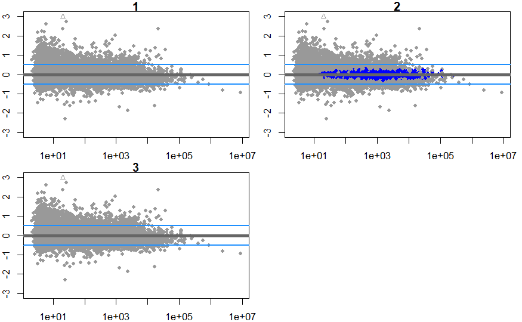

```r
plotMA(resG, ylim=ylim, cex=0.8, main="3"); drawLines()
plotMA(resL, ylim=ylim, cex=0.8, main="4"); drawLines()
```

## Tests of log2 fold change above or below a threshold (deseq_cod_dm)

1.greaterAbs - |β|>x - tests are two-tailed  
2.lessAbs - |β|<x - p values are the maximum of the upper and lower tests  
3.greater - β>x  
4.less - β<−x

```r
par(mfrow=c(2,2),mar=c(2,2,1,1))
ylim <- c(-3, 3)
resGA <- results(deseq_cod_dm, lfcThreshold=.5, altHypothesis="greaterAbs")
resLA <- results(deseq_cod_dm, lfcThreshold=.5, altHypothesis="lessAbs")
resG <- results(deseq_cod_dm, lfcThreshold=.5, altHypothesis="greater")
resL <- results(deseq_cod_dm, lfcThreshold=.5, altHypothesis="less")
drawLines <- function() abline(h=c(-.5,.5),col="dodgerblue",lwd=2)
plotMA(resGA, ylim=ylim, cex=0.8, main="1"); drawLines()
plotMA(resLA, ylim=ylim, cex=0.8, main="2"); drawLines()
```

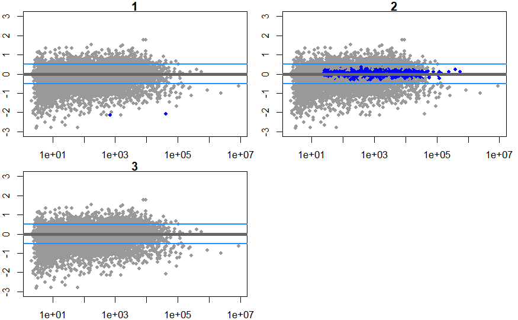

```r
plotMA(resG, ylim=ylim, cex=0.8, main="3"); drawLines()
plotMA(resL, ylim=ylim, cex=0.8, main="4"); drawLines()
```

## Tests of log2 fold change above or below a threshold (deseq_cod_dm_covid_only)

1.greaterAbs - |β|>x - tests are two-tailed  
2.lessAbs - |β|<x - p values are the maximum of the upper and lower tests  
3.greater - β>x  
4.less - β<−x

```r
par(mfrow=c(2,2),mar=c(2,2,1,1))
ylim <- c(-3, 3)
resGA <- results(deseq_cod_dm_covid_only, lfcThreshold=.5, altHypothesis="greaterAbs")
resLA <- results(deseq_cod_dm_covid_only, lfcThreshold=.5, altHypothesis="lessAbs")
resG <- results(deseq_cod_dm_covid_only, lfcThreshold=.5, altHypothesis="greater")
resL <- results(deseq_cod_dm_covid_only, lfcThreshold=.5, altHypothesis="less")
drawLines <- function() abline(h=c(-.5,.5),col="dodgerblue",lwd=2)
plotMA(resGA, ylim=ylim, cex=0.8, main="1"); drawLines()
plotMA(resLA, ylim=ylim, cex=0.8, main="2"); drawLines()
```

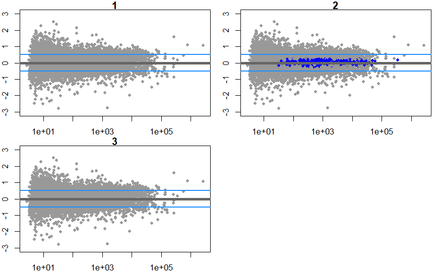

```r
plotMA(resG, ylim=ylim, cex=0.8, main="3"); drawLines()
plotMA(resL, ylim=ylim, cex=0.8, main="4"); drawLines()
```

# Decision Tree

[figure not shown]

```r
fit <- rpart(Reason_for_Admission~`Study Group`, data=rfa)
plot(fit)
text(fit)
```

# Decision Tree

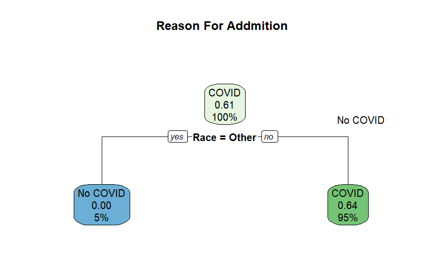

```r
fit <- rpart(`Study Group`~ Expired + Race , data=rfa,
             method="class")

rpart.plot(fit, main = "Reason For Addmition")
text(fit)
```